# F0 Varations for Single Syllable French Words

### 5.1.2 Neutralization

Let’s go in the opposite direction. What is the minimum amount of f0 change for the stimli to still get perceived as an exclamation?

```r
# Still the same file
my_path <- "../data/prosogram-results/syllab1/"
name <- "flute_h"

filename <- str_c(my_path,"pitchtier/",name, "_styl.PitchTier")
mpt <- pt.read(filename)

deltas <- seq(0, 1.5, by=0.25)

# this time we set the interval, changing f[1]
lapply(deltas, function(elt) {
  write_resynthesis_file(set_interval(mpt, elt, 1, 2), my_path, name, str_c("smaller", elt, "t1"))
})
```

To my ears, when we get below 1 semitone change, it starts to sound less like an exclamation.

1 semitone descente:

[interactive chart not shown]

0.75 semitones descente:

[interactive chart not shown]

0.5 semitones descente:

[interactive chart not shown]

0.25 semitones descente:

[interactive chart not shown]

0 semitones descente:

[interactive chart not shown]

## 5.2 Simple Montée

### 5.2.1 Exaggeration

[interactive chart not shown]

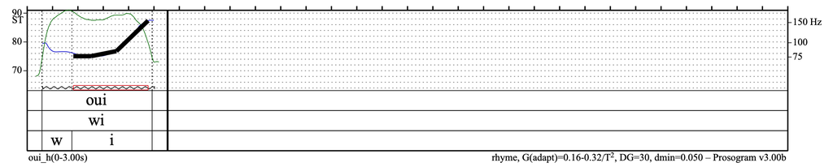

```r
# Load Pitchtier
my_path <- "../data/prosogram-results/syllab1/"
name <- "oui_h"

filename <- str_c(my_path,"pitchtier/",name, "_styl.PitchTier")
mpt <- pt.read(filename)

# Amounts to change by
deltas <- seq(2, 24, by=2)

# Move the last point (mpt$t[4]) even lower by increments in deltas
lapply(deltas, function(elt) {
  write_resynthesis_file(modify_interval(mpt, elt, 4), my_path, name, str_c("higher", elt, "t4"))
})
```

End up 2ST:

[interactive chart not shown]

End up 6ST:

[interactive chart not shown]

End up 12ST:

[interactive chart not shown]

End up 14ST:

[interactive chart not shown]

To my ears, up to 12ST beyond the original 6.27ST change (18.27 ST total) sound plausible. Once we get to +14ST, it starts to sound too much. Even montées of 18ST are unlikely in real life due to limits of the voice. This shows that the amount of montée once beyond a certain point is quite flexible.

### 5.2.2 Neutralization

```r
# Load Pitchtier
my_path <- "../data/prosogram-results/syllab1/"
name <- "oui_h"

filename <- str_c(my_path,"pitchtier/",name, "_styl.PitchTier")
mpt <- pt.read(filename)

# Amounts to change by
deltas <- seq(0, 6, by=2)
lapply(deltas, function(elt) {
  write_resynthesis_file(set_interval(mpt, elt, 4), my_path, name, str_c("smaller", elt, "t4"))
})
```

0ST up in last segment:

[interactive chart not shown]

2ST up in last segment:

[interactive chart not shown]

4ST up in last segment:

[interactive chart not shown]

We can still hear a bit of a montée because this pronunciation has a non-linear montée curve. I am only changing the amount of montée in the last segment, but there is still 1.73 ST montée in the first two segments.

Looking at a different file, this one rises in a single linear segment.

Original file: 12.6ST montée:

[interactive chart not shown]

[figure not shown]

```r
# Load Pitchtier
my_path <- "../data/prosogram-results/syllab1/"
name <- "oui_f"

filename <- str_c(my_path,"pitchtier/",name, "_styl.PitchTier")
mpt <- pt.read(filename)

# Amounts to change by
deltas <- seq(0, 2, by=0.5)
lapply(deltas, function(elt) {
  write_resynthesis_file(set_interval(mpt, elt, 2), my_path, name, str_c("smaller", elt, "t4"))
})
```

2ST montée:

[interactive chart not shown]

1.5ST montée:

[interactive chart not shown]

1ST montée:

[interactive chart not shown]

These ones have a montée but they sound less like a question. It’s more like someone saying “Yes, but…” which is known as a continuation. Or someone answering the phone after being woken up from sleep in the middle of the night.

## 5.3 Descente With Initial Montée

Here’s an example of a stimuli that sounds like a descente, but its f0 curve has a montée in the beginning that is almost as large as the descente.

Original file: 3.84ST initial montée, 3.92ST descente

[interactive chart not shown]

[figure not shown]

I’m interested in what it sound like when

- The initial montée is neutralized
- The initial montée is exaggerated

### 5.3.1 Neutralize Initial Segment

#### 5.3.1.1 Flatten Initial Segment

First, let’s keep the two-segment f0 contour and make the first part of the contour flat instead of rising. The descente part of the contour remains unchangegd.

```r
# Load Pitchtier
my_path <- "../data/prosogram-results/syllab1/"
name <- "bien_h"

filename <- str_c(my_path,"pitchtier/",name, "_styl.PitchTier")
mpt <- pt.read(filename)

write_resynthesis_file(set_interval(mpt, 0, 1, 2), my_path, name, str_c("no-initial-rise"))
```

Result:

[interactive chart not shown]

To me, this sound like the person is less enthusiastic than the original, but the difference is pretty subtle.

#### 5.3.1.2 Eliminate Initial Segment

We can also try to make the stimuli strictly descending, by getting rid of the bend in the contour.

```r
# Load Pitchtier
my_path <- "../data/prosogram-results/syllab1/"
name <- "bien_h"

filename <- str_c(my_path,"pitchtier/",name, "_styl.PitchTier")
mpt <- pt.read(filename)

mpt_new <- mpt
mpt_new$f[1] <- mpt$f[2]
mpt_new$f[2] <- mpt$f[3]
mpt_new$t[2] <- mpt$t[3]
mpt_new$f <- head(mpt_new$f,-1)
mpt_new$t <- head(mpt_new$t,-1)

write_resynthesis_file(mpt_new, my_path, name, str_c("fall"))
```

Result:

[interactive chart not shown]

This also sound less enthusiastic than the original. Also a subtle difference.

### 5.3.2 Exaggerate Initial Segment

#### 5.3.2.1 Increase Size of Initial Segment

We can move the initial point of the f0 curve lower. Recall that we already have 3.84ST montée in the beginning.

```r
# Load Pitchtier
my_path <- "../data/prosogram-results/syllab1/"
name <- "bien_h"

filename <- str_c(my_path,"pitchtier/",name, "_styl.PitchTier")
mpt <- pt.read(filename)

# Amounts to change by
deltas <- seq(2, 16, by=2)
lapply(deltas, function(elt) {
  write_resynthesis_file(modify_interval(mpt, -elt, 1, 2), my_path, name, str_c("bigger-montee", elt))
})
```

3.84ST + 2ST montée:

[interactive chart not shown]

3.84ST + 6ST montée:

[interactive chart not shown]

3.84ST + 14ST montée:

[interactive chart not shown]

It starts to sound unnatural when the voice starts that low, but the expression doesn’t drastically change.

#### 5.3.2.2 Increase Duration of Initial Segment

From 0 to 1 of syllable nucleus, where does the descent start?

```r
my_path <- "../data/prosogram-results/syllab1/"
name <- "bien_h"

filename <- str_c(my_path,"pitchtier/",name, "_styl.PitchTier")
mpt <- pt.read(filename)

(mpt$t[2]-mpt$t[1])/(mpt$t[3]-mpt$t[1])
```

```
## [1] 0.5588235
```

Let’s move the beginning of the descente half way between where it currently is and the end of the syllable nucleus.

```r
# Load Pitchtier
my_path <- "../data/prosogram-results/syllab1/"
name <- "bien_h"

filename <- str_c(my_path,"pitchtier/",name, "_styl.PitchTier")
mpt <- pt.read(filename)

mpt_new <- mpt
mpt_new$t[2] <- mpt$t[2] + (mpt$t[3] - mpt$t[2])/2

write_resynthesis_file(mpt_new, my_path, name, str_c("later-fall1"))
```

The result no longer sounds like a desente and instead sounds like a montée!

[interactive chart not shown]

## 5.4 Montée with Initial Descente

Original file: 2.2ST initial descente, 4.28ST montée

[interactive chart not shown]

[figure not shown]

### 5.4.1 Neutralize Initial Segment

#### 5.4.1.1 Flatten Initial Segment

I don’t think that flattening the initial descente will significantly change the expression of the output stimuli. Below is another word pronounced by the same speaker with a similar sounding expression that has a flat f0 segment followed by a montée.

[interactive chart not shown]

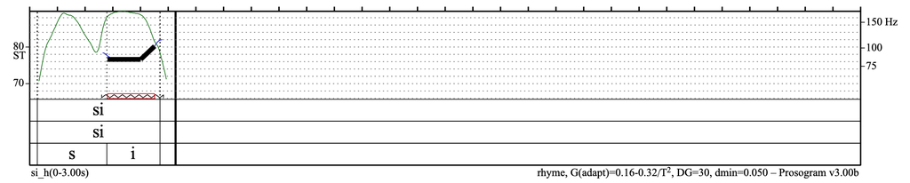

#### 5.4.1.2 Eliminate Initial Segment

```r
# Load Pitchtier
my_path <- "../data/prosogram-results/syllab1/"
name <- "non_h"

filename <- str_c(my_path,"pitchtier/",name, "_styl.PitchTier")
mpt <- pt.read(filename)

mpt_new <- mpt
mpt_new$f[1] <- mpt$f[2]
mpt_new$f[2] <- mpt$f[3]
mpt_new$t[2] <- mpt$t[3]
mpt_new$f <- head(mpt_new$f,-1)
mpt_new$t <- head(mpt_new$t,-1)

write_resynthesis_file(mpt_new, my_path, name, str_c("rise"))
```

The result still sound like a question but less contradictory than the initial stimuli.

[interactive chart not shown]

### 5.4.2 Exaggerate Initial Segment

#### 5.4.2.1 Increase Sizeof Initial Segment

The stimuli already has 2.2ST descente at the beginning. What happens when we increase this amount? We can do so by raising the f0 at the starting point of the stimuli.

```r
# Load Pitchtier
my_path <- "../data/prosogram-results/syllab1/"
name <- "non_h"

filename <- str_c(my_path,"pitchtier/",name, "_styl.PitchTier")
mpt <- pt.read(filename)

# Amounts to change by
deltas <- seq(2, 16, by=2)
lapply(deltas, function(elt) {
  write_resynthesis_file(modify_interval(mpt, elt, 1, 2), my_path, name, str_c("bigger-descente", elt))
})
```

A similar expression as the original stimuli:  
2.2ST + 2ST descente:

[interactive chart not shown]

Starts to sound ambiguous  
2.2ST + 4ST descente:

[interactive chart not shown]

More than 6ST increase in descente makes the entire phrase sound like a statement rather than question.  
2.2ST + 6ST descente:

[interactive chart not shown]

2.2ST + 8ST descente:

[interactive chart not shown]

A large initial descente followed by a small montée sounds like the speaker is annoyed.  
2.2ST + 12ST descente:

[interactive chart not shown]

#### 5.4.2.2 Increase Duration of Initial Segment

From 0 to 1 of syllable nucleus, where does the montée start?

```r
# Load Pitchtier
my_path <- "../data/prosogram-results/syllab1/"
name <- "non_h"
filename <- str_c(my_path,"pitchtier/",name, "_styl.PitchTier")
mpt <- pt.read(filename)
(mpt$t[2]-mpt$t[1])/(mpt$t[3]-mpt$t[1])
```

```
## [1] 0.6666667
```

It’s already about 2/3 of the way through syllable nucleus. Let’s try a few more timings.

```r
# Load Pitchtier
my_path <- "../data/prosogram-results/syllab1/"
name <- "non_h"

filename <- str_c(my_path,"pitchtier/",name, "_styl.PitchTier")
mpt <- pt.read(filename)

# Inflection point at 50% of syllable nucleus
mpt_new <- mpt
mpt_new$t[2] <-  mpt$t[1] + (mpt$t[3] - mpt$t[1])*0.5
write_resynthesis_file(mpt_new, my_path, name, str_c("later-rise50"))

# Inflection point at 80% of syllable nucleus
mpt_new <- mpt
mpt_new$t[2] <- mpt$t[1]+ (mpt$t[3] - mpt$t[1])*0.80
write_resynthesis_file(mpt_new, my_path, name, str_c("later-rise80"))

# Inflection point at 90% of syllable nucleus
mpt_new <- mpt
mpt_new$t[2] <- mpt$t[1] + (mpt$t[3] - mpt$t[1])*0.9
write_resynthesis_file(mpt_new, my_path, name, str_c("later-rise90"))

# Inflection point at 95% of syllable nucleus
mpt_new <- mpt
mpt_new$t[2] <- mpt$t[1] + (mpt$t[3] - mpt$t[1])*0.95
write_resynthesis_file(mpt_new, my_path, name, str_c("later-rise95"))
```

As a control, I moved the inflection point to 50% of the syllable nucleus, reducing instead of increasing the length of the initial descente. The result doesn’t sound so different from the original stimuli.  
Inflection point at 50% of syllable nucleus:

[interactive chart not shown]

The following synthesized stimuli increase the length of the initial descente. These sound very ambiguous to me. Even when the inflection point at is 95%, it still does not fully sound like a descente.  
Inflection point at 80% of syllable nucleus:

[interactive chart not shown]

Inflection point at 90% of syllable nucleus:

[interactive chart not shown]

Inflection point at 95% of syllable nucleus:

[interactive chart not shown]